# Contact rates datasets

David Champredon

2016-12-01

## Objectives

Estimate the the typical contact rates from various social settings relevant for influenza transmission in Ontario.

## Data sources

To my knowledge, there is no such data for Ontario. However, proximity studies have been conducted in similar settings, in particular in France.

The data were downloaded from the SocioPatterns website (http://www.sociopatterns.org/datasets/) that collected proximity data from sensors worn by individuals in various social settings (e.g. workplace, schools,…).

**Important note:** Here I look at the number of contacts without double counting when several contacts are made with the same individual over a day. So the contact numbers are smaller than most of the ones published (which generally counts *all* contacts).

- data for the workplace were downloaded from http://www.sociopatterns.org/datasets/contacts-in-a-workplace/ and published in *Génois M, Vestergaard CL, Fournet J, Panisson A, Bonmarin I, Barrat A. Data on face-to-face contacts in an office building suggest a low-cost vaccination strategy based on community linkers. Network Science 2015; 3: 326–47.*
- data for the high school were downloaded from http://www.sociopatterns.org/datasets/high-school-dynamic-contact-networks/ and published in *Fournet J, Barrat A. Contact Patterns among High School Students. PLoS ONE 2014; 9: e107878.*
- data for the primary school were downloaded from the supplementary material of *Stehlé J, Voirin N, Barrat A, et al. High-Resolution Measurements of Face-to-Face Contact Patterns in a Primary School. PLoS ONE 2011; 6: e23176.*

## Published results

- In primary school, children had on average 323 contacts per day with 47 distinct other children
- In the high school, students had on average 110 (=19774/180) contacts per day
- In the office building, no such stats published.
- The distributions of normalized degree, contact durations, inter-contact durations and link weight were similar between studies of i) office building, ii) conference and iii) high school. See Genois 2015, Figure 2. The duration of contact distribution for primary school is also similar to these 3 other setting (Genois 2015 Fig 2 and Stehle 2011 Fig 3).

## Short statistical analysis

Data for the primary school is not the same format as the dat for workplace and high school, so identical statistical analysis could not be performed exactly the same way (in the short amount of time available!).

### Workplace

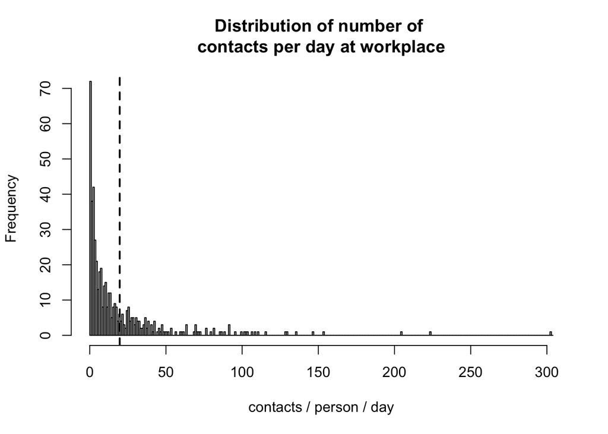

```
##    Min. 1st Qu.  Median    Mean 3rd Qu.    Max.
##    1.00    3.00    8.50   19.65   25.00  303.00
```

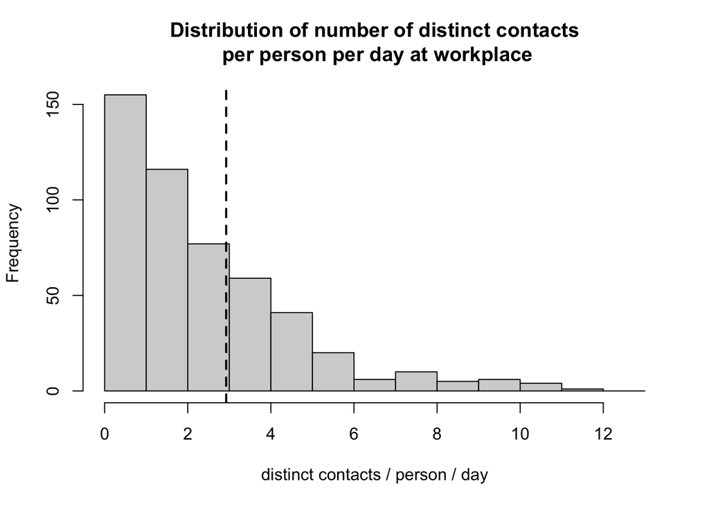

```
##    Min. 1st Qu.  Median    Mean 3rd Qu.    Max.
##   1.000   1.000   2.000   2.924   4.000  12.000
```

The mean contact rate is 19.65 contacts per person per day, and a standard deviation of 30.69. The number of distinct contacts per person per day is 2.92.

### Primary school

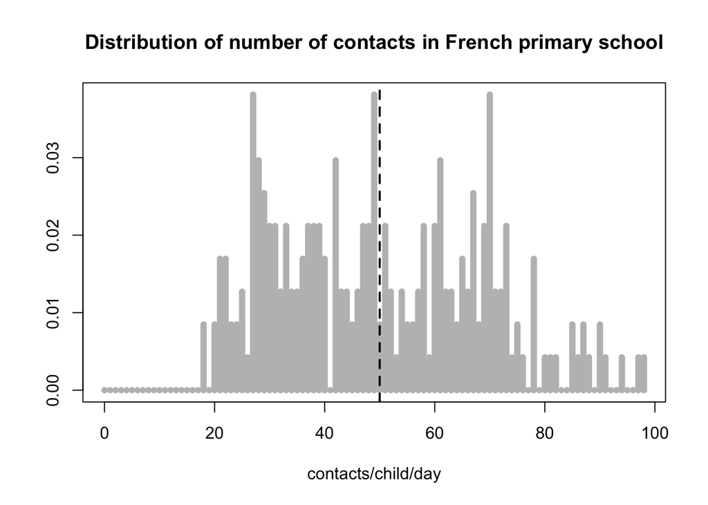

For the French primary school, the mean contact rate is 49.99 with a standard deviation of 18.91.

### High school

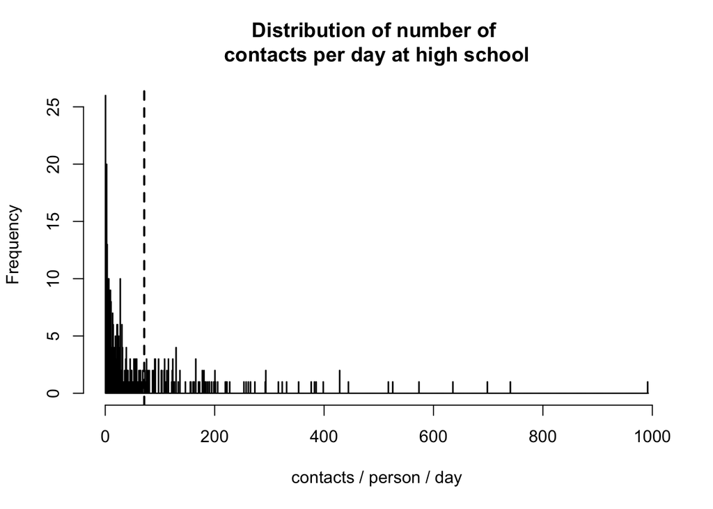

```
##    Min. 1st Qu.  Median    Mean 3rd Qu.    Max.
##    1.00    7.00   28.00   71.22   87.00  992.00
```

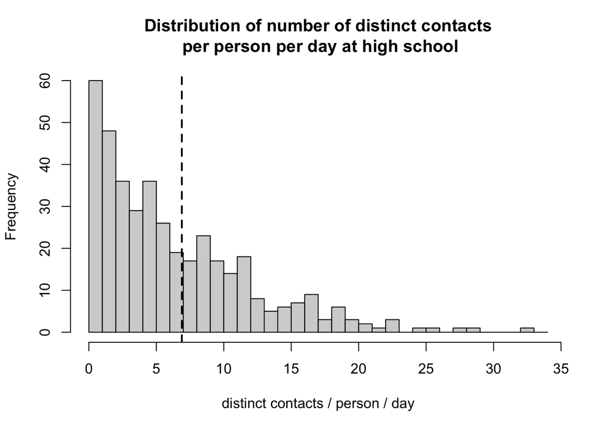

```
##    Min. 1st Qu.  Median    Mean 3rd Qu.    Max.
##    1.00    2.00    5.00    6.89   10.00   33.00
```

The mean contact rate for high school student is 71.22 contacts per person per day, and a standard deviation of 116.2.

### Comparison between the 3 studies

Comparison of the number of contacts per day per individual and the number of distinct contacts per day per individual.

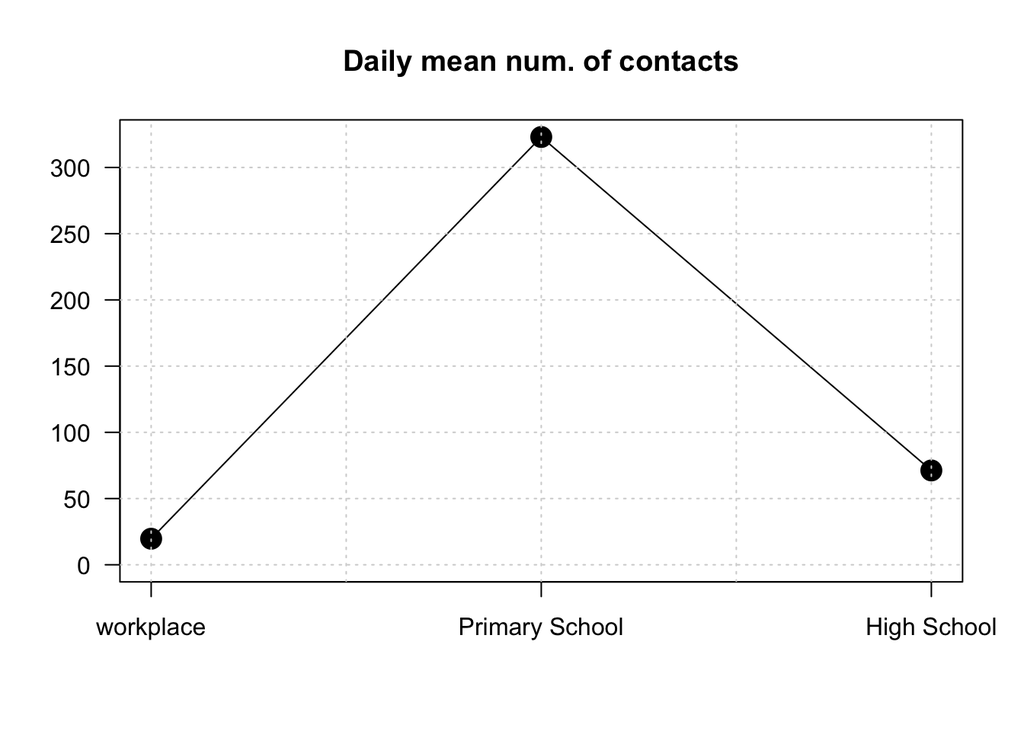

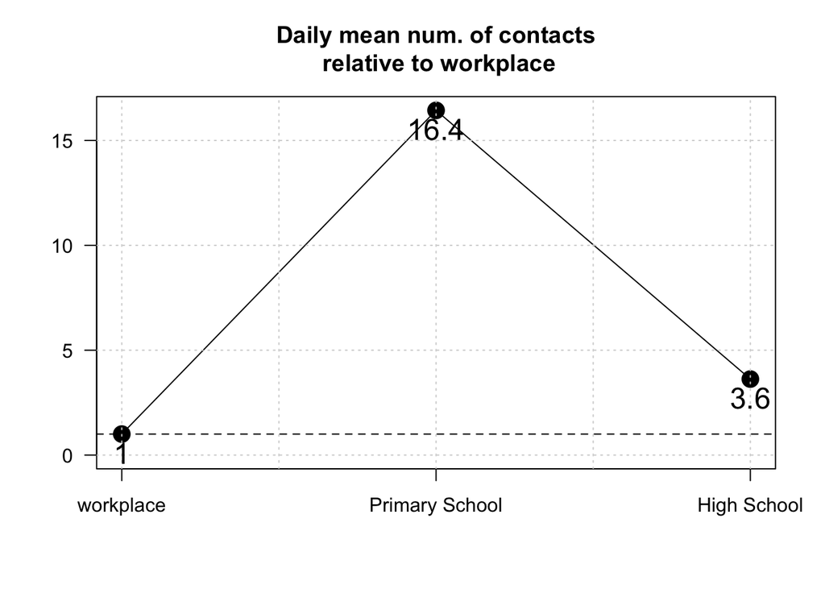

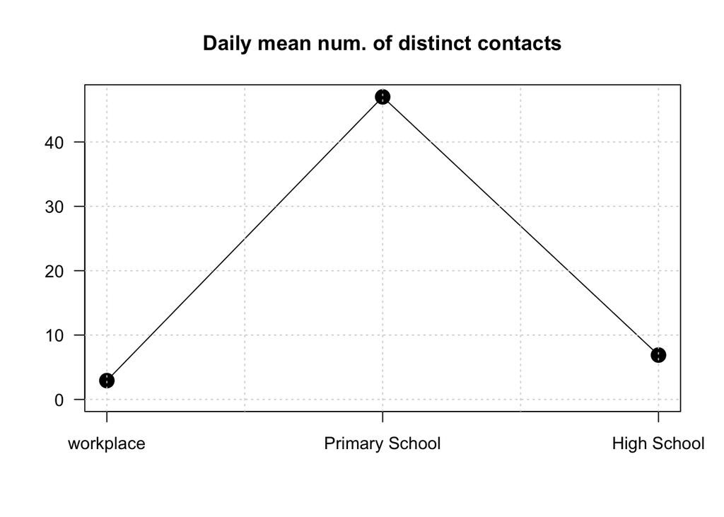

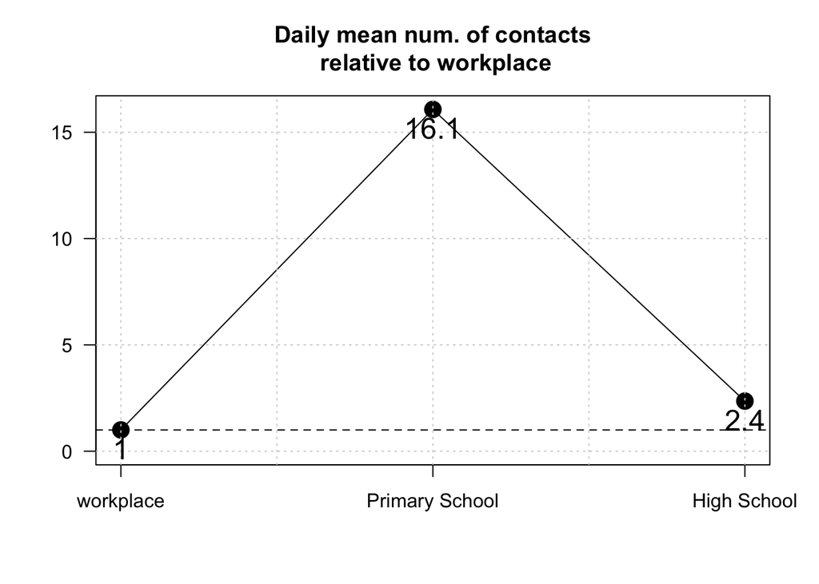

## Other publications

The study by Toth et al (RS Interface, 2015) reports more distinct contacts forchildren in elementary and middle schools in Utah, USA. It found 52-76 distinct contacts per individual per day (over 2 days) for elementary school pupils, and about 130 for children in middle school. (*Toth DJA, Leecaster M, Pettey WBP, et al. The role of heterogeneity in contact timing and duration in network models of influenza spread in schools. Journal of The Royal Society Interface 2015; 12: 20150279.*)

Unfortunately, there is not a “parallel” study in the same geographical location (e.g. Utah) for the workplace in order to make a similar comparison as done in France.